# dsci_project_nirushanbhag

Niru Shanbhag

4/23/2023

```r
library(tidyverse)
```

```r
library(dplyr)
library(ggplot2)
library(lubridate)
```

## FINAL PROJECT

dataset = https://www.kaggle.com/datasets/rodsaldanha/arketing-campaign/discussion/182997

```r
#Preparing the data
cust <- read.csv("/Users/nirushanbhag/Downloads/DSCI101/DSCI101/data/marketing_campaign.csv", sep = "\t")
cust <- cust %>% filter(!is.na(Income)) #remove all the Incomes that are NA
cust$Dt_Customer = dmy(cust$Dt_Customer)
cust <- cust %>% mutate(income_bracket =
                  cut(Income, breaks = c(-Inf, 25000, 50000, 75000, 100000, 200000, 300000, 400000, 500000, 600000,700000),
                  include.lowest = FALSE,
                  labels = c("<25K", "25K-50K", "50K-75K", "75K-100K", "100K-200K", "200K-300K", "300K-400K", "400K-500K", "500K-600K", "600K-700K")),
                  no_offspring = Teenhome + Kidhome,
                  month_of_enrollment = month(Dt_Customer),
                  year_at_enrollment= year(Dt_Customer),
                  age_at_enrollment = year_at_enrollment - Year_Birth,
                  age_bracket =
                  cut(age_at_enrollment, breaks = c(-Inf, 19, 29, 39, 49, 59, 69, 79, 89, 99, Inf), labels = c("Teens", "20s", "30s", "40s", "50s", "60s", "70s", "80s", "90s", "100s")),
                  total_amount_purchased = NumWebPurchases+NumCatalogPurchases+NumStorePurchases+NumDealsPurchases
)
```

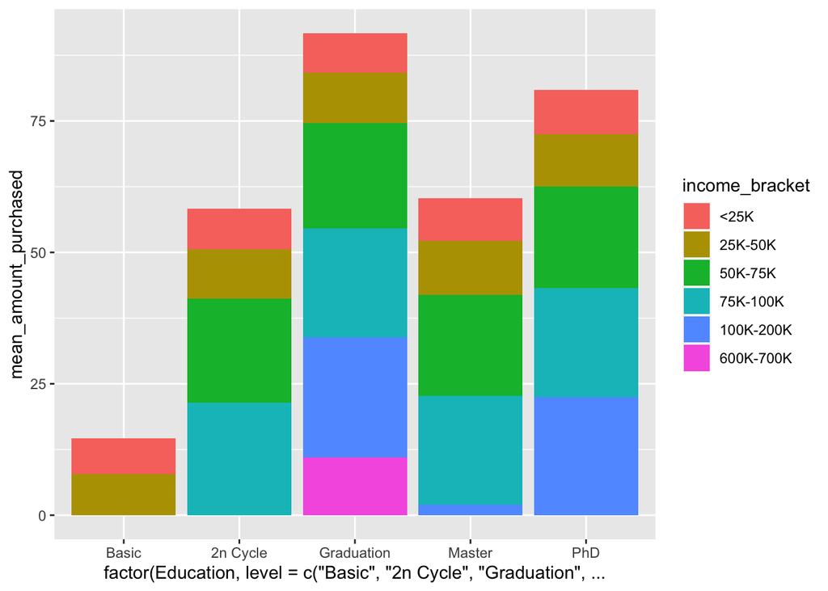

```r
cust %>% group_by(Education, income_bracket) %>% summarize(mean_amount_purchased = mean(total_amount_purchased)) %>% ggplot(aes(x = factor(Education, level = c("Basic", "2n Cycle", "Graduation", "Master", "PhD")), y = mean_amount_purchased, fill = income_bracket)) + geom_bar(stat = "identity")
```

1b.Find the group within education, marital_status, and income that have the highest average amount purchased.  
People in the bracket who have a PhD, are married, and are in the income bracket of 100-200K who have 1 kid have the highest average amount purchased. This makes sense because having a high degree and being married usually means you tend to have a stable source of income, since at least one partner is contributing to the income. Having a child at home also means you probably make more purchases

```r
cust %>% group_by(Education, Marital_Status, income_bracket, no_offspring) %>% summarize(mean_amount_purchased = mean(total_amount_purchased)) %>% arrange(-mean_amount_purchased)
```

[output not shown]

```
## # A tibble: 247 × 5
## # Groups:   Education, Marital_Status, income_bracket [97]
##    Education  Marital_Status income_bracket no_offspring mean_amount_purchased
##    <chr>      <chr>          <fct>                 <int>                 <dbl>
##  1 PhD        Married        100K-200K                 1                    37
##  2 Graduation Married        75K-100K                  2                    29
##  3 Graduation Single         75K-100K                  3                    29
##  4 Graduation Together       100K-200K                 0                    29
##  5 2n Cycle   Divorced       25K-50K                   0                    28
##  6 2n Cycle   Widow          50K-75K                   1                    27
##  7 Graduation Single         100K-200K                 0                    27
##  8 PhD        Single         100K-200K                 0                    27
##  9 2n Cycle   Divorced       50K-75K                   0                    26
## 10 PhD        Together       100K-200K                 0                    26
## # ℹ 237 more rows
```

2. Visualize the visits to purchase ratio based on the income bracket

It looks like for the most part, the median of visits to purchase ratio drastically decreases (meaning that they make more purchases than visits) as we go up the income bracket.  
This link helped with getting rid of outliers and setting a limit on the y axis: https://stackoverflow.com/questions/5677885/ignore-outliers-in-ggplot2-boxplot

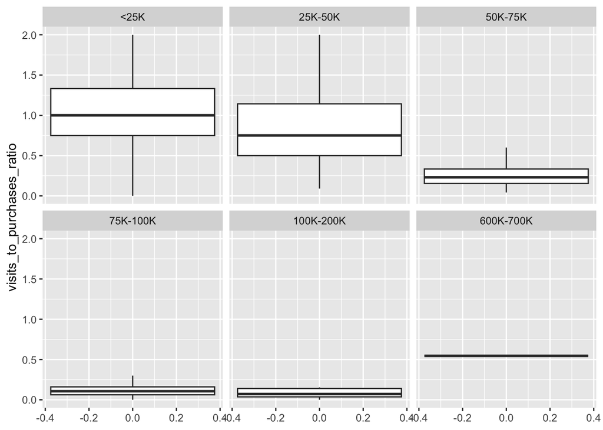

```r
#any number greater than 1 means that they visited more than they purchased
cust %>% mutate(visits_to_purchases_ratio = (NumWebVisitsMonth/(NumWebPurchases+NumCatalogPurchases+NumStorePurchases+NumDealsPurchases))) %>% filter(visits_to_purchases_ratio != "Inf") %>% ggplot(aes(y = visits_to_purchases_ratio)) + geom_boxplot(outlier.shape = NA) + scale_y_continuous(limits = c(0, 2)) + facet_wrap(~income_bracket)
```

3. Visualize the age bracket and average number of recency (how many days pass between purchases). Do this again for income bracket.

The age bracket that has the highest recency, or number of days that pass between purchases, are people in their 70s and the bracket with the lowest recency are people in their 30s. But all brackets pretty much have around the same average recency. What about income bracket?  
The income bracket that has the lowest recency, or number of days that pass between purchases, are people making 600K-700K, and highest recency are people making <25K.

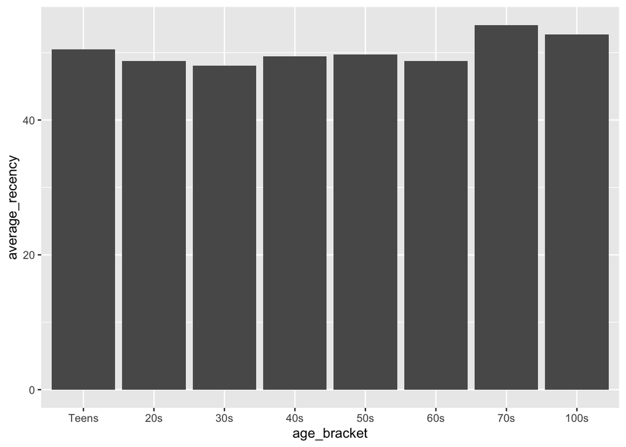

```r
cust  %>% group_by(age_bracket) %>% summarize(average_recency = mean(Recency)) %>% arrange(-average_recency) %>% ggplot(aes(x = age_bracket, y = average_recency)) + geom_bar(stat = "identity")
```

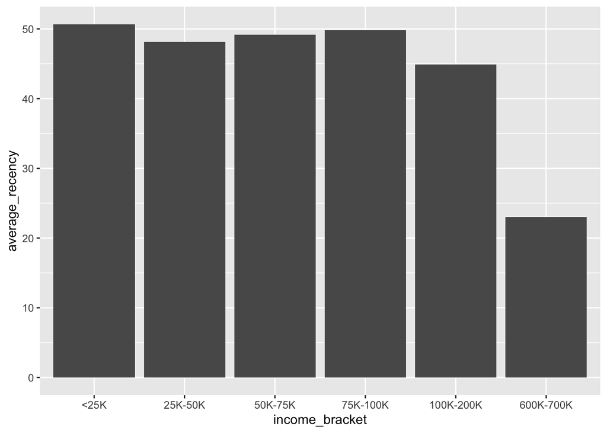

```r
cust  %>% group_by(income_bracket) %>% summarize(average_recency = mean(Recency)) %>% arrange(-average_recency) %>% ggplot(aes(x = income_bracket, y = average_recency)) + geom_bar(stat = "identity")
```

4. Which education, marital_status, and income groups engage the most with marketing campaigns and which do not engage with marketing campaigns?

The income bracket 75-100K had the largest marketing campaign engagement “score”, and the 600-700K had the lowest.

```r
cust %>% mutate(engagement_score = rowMeans(across(c(AcceptedCmp1, AcceptedCmp2, AcceptedCmp3, AcceptedCmp4, AcceptedCmp5))))  %>% group_by(income_bracket) %>% summarize(grouped_mean_engagement_sum = sum(engagement_score)) %>% arrange(-grouped_mean_engagement_sum)
```

```
## # A tibble: 6 × 2
##   income_bracket grouped_mean_engagement_sum
##   <fct>                                <dbl>
## 1 75K-100K                              65.4
## 2 50K-75K                               41.8
## 3 25K-50K                               18.6
## 4 <25K                                   4
## 5 100K-200K                              2.4
## 6 600K-700K                              0
```

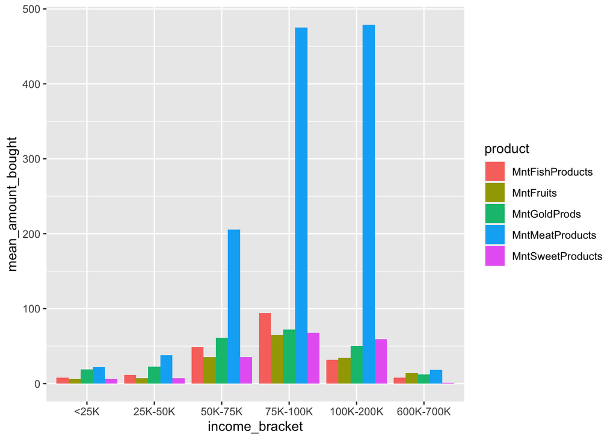

```r
cust %>% group_by(income_bracket) %>% summarise(across(c(MntFruits, MntMeatProducts, MntFishProducts, MntSweetProducts, MntGoldProds), mean, na.rm = TRUE))  %>% pivot_longer(cols = c(MntFruits, MntMeatProducts, MntFishProducts, MntSweetProducts, MntGoldProds), names_to = 'product', values_to = "mean_amount_bought")  %>%  ggplot(aes(x = income_bracket, y = mean_amount_bought, fill = product)) + geom_bar(stat = "identity", position = position_dodge())
```

You can’t really tell if there’s a trend, but the peak of highest total amount purchased comes from middle aged people and most of the colors at the peak are 2n cycle, graduation, master, and PhD.

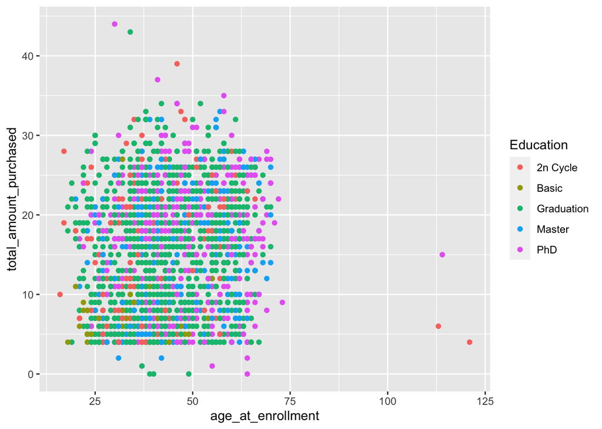

```r
cust %>% ggplot(aes(x = age_at_enrollment, y = total_amount_purchased, color = Education)) + geom_point()
```